# Using R

Göran Broström

2016-11-30

## What is R?

**R** is

- a language and environment for *statistical computing* and *graphics*.
- a *GNU project* originating from the *S* language and environment which was developed at *Bell Laboratories* (formerly AT&T, now Lucent Technologies) by *John Chambers* and colleagues.
- a different implementation of S.
- 25 years old.

From [The R project](http://www.r-project.org/about.html)

## What is R?

- R provides a wide variety of statistical and graphical techniques, and is *highly extensible*.
- One of R’s strengths is the ease with which *well-designed publication-quality plots* can be produced, including mathematical symbols and formulae where needed.

## The R environment

**R** includes

- an effective *data handling* and *storage* facility,
- operators for *calculations on arrays*, in particular *matrices*,
- intermediate *tools for data analysis*,
- superb *graphical facilities*, and
- a simple and effective *programming language* which includes
  - *conditionals*,
  - *loops*,
  - user-defined recursive functions and
  - *input* and *output* facilities.

## Why R?

- **R** is *free*:
  - as in *free beer*,
  - as in *free speech*.
- **R** can be installed on as many computers you like
- **R** is *open-source*.
- **R** has thousands (7000+ today) of *add-on packages*.

## What is RStudio?

RStudio allows you to *run R* in a more *user-friendly* environment

- It is *free* and *open-source*,
- Tools for *interacting* statistical *analysis* with report *writing*.
  - *R markdown*
  - *knitr*
  - LaTeX
- Tools for *version control* (git, gitHub)
- [Support](http://www.rstudio.com).

## Why RStudio?

Also,

- It is *available* on all (Linux, Mac, Windows) platforms.
- It looks *exactly the same* on all platforms.
  - It *behaves exactly the same* on all platforms.

## What is reproducible research?

- It can be *reproduced by others*,
- It can be reproduced *by yourself* (6 months later)!

Focus is on reproducing results *from a single set of observations*.

## What is reproducible research *not*?

- We do *not* mean *replicable*.
  - **Replicable:** If the *results* can be replicated on *another* study population.
- It is rather about rules of *disciplin* and *documentation*.
- *RStudio* gives you the *tools*.

## Version control

- Must be *easy* to go back to *earlier versions* of your research:
  - You detect *errors*,
  - You get *new data*,
  - The journal asks you to perform *separate analyses* for men and women,
  - etc.
- There are *tools* to help:
  - [git](http://git-scm.com), by Linus Torvalds,
    - [gitHub](https://github.com)

## Analysis

I want to study infant mortality with data from the file *observation*. So I load it, and also the file *person*.

```r
load("data/observation.rda")
load("data/person.rda")
```

There are some redundant information in *observation* which we remove:

```r
names(observation)
```

```
##  [1] "idi"        "date"       "birth_date" "present"    "occupation"
##  [6] "married"    "firstRec"   "lastRec"    "enter"      "date2"
## [11] "exit"       "death_date" "sex"        "event"      "m_idi"
```

## Load dplyr

```r
library(dplyr)
obs <- select(observation, idi, birthdate = birth_date, sex, occupation, married, enter, exit, event, m_idi)
summary(obs)
```

```
##       idi             birthdate              sex
##  Min.   :10000192   Min.   :1723-02-07   Length:59222
##  1st Qu.:12470638   1st Qu.:1815-11-11   Class :character
##  Median :14968014   Median :1838-06-19   Mode  :character
##  Mean   :14975615   Mean   :1834-11-28
##  3rd Qu.:17458233   3rd Qu.:1858-05-11
##  Max.   :19999699   Max.   :1901-12-08
##
##    occupation      married            enter             exit
##  Min.   :    -1   Mode :logical   Min.   :-0.383   Min.   :  0.003
##  1st Qu.:     0   FALSE:49634     1st Qu.: 0.000   1st Qu.: 20.849
##  Median :     0   TRUE :9588      Median : 0.000   Median : 25.944
##  Mean   : 26600   NA's :0         Mean   :13.113   Mean   : 28.679
##  3rd Qu.: 61110                   3rd Qu.:25.588   3rd Qu.: 33.528
##  Max.   :211110                   Max.   :88.684   Max.   :100.467
##
##    event             m_idi
##  Mode :logical   Min.   :10000250
##  FALSE:41163     1st Qu.:12487398
##  TRUE :18059     Median :15058952
##  NA's :0         Mean   :15020780
##                  3rd Qu.:17535684
##                  Max.   :19999878
##                  NA's   :6231
```

## Glitches

There are some glitches here: A quick fix:

```r
obs$enter <- pmax(obs$enter, 0)
with(obs, sum(exit - enter <= 0))
```

```
## [1] 0
```

Good!

## The occupation:

```r
obs <- filter(obs, occupation < 100000)
obs$occ <- cut(obs$occupation, seq(1:10) * 10000, right = FALSE,
               labels = 1:9)
with(obs,  table(event, occ))
```

```
##        occ
## event       1     2     3     4     5     6     7     8     9
##   FALSE   172   121   196   160   649 14968   570   297  1952
##   TRUE     43    11    26    23   227  4333   104    32   406
```

## First survival analysis

```r
library(eha)
fit <- coxreg(Surv(enter, exit, event) ~ occ, data = obs)
##drop1(fit, test = "Chisq")
```

## The coefficients

```r
summary(fit)
```

```
## Call:
## coxreg(formula = Surv(enter, exit, event) ~ occ, data = obs)
##
## Covariate           Mean       Coef     Rel.Risk   S.E.    Wald p
## occ
##                1    0.008     0         1 (reference)
##                2    0.002     0.185     1.204     0.338     0.583
##                3    0.007     0.028     1.029     0.249     0.909
##                4    0.004     0.441     1.553     0.259     0.088
##                5    0.043    -0.134     0.874     0.166     0.419
##                6    0.851    -0.142     0.868     0.153     0.354
##                7    0.020     0.055     1.056     0.181     0.763
##                8    0.007     0.079     1.083     0.234     0.734
##                9    0.059     0.232     1.261     0.160     0.148
##
## Events                    5205
## Total time at risk        191137
## Max. log. likelihood      -39285
## LR test statistic         58.27
## Degrees of freedom        8
## Overall p-value           1.01616e-09
```

## Mother’s age

```r
obs$birthdate <- as.numeric(toTime(obs$birthdate))
indx <- match(obs$m_idi, person$idi)
obs$m.birthdate <- person$birth_date[indx]
obs$m.birthdate <- as.numeric(toTime(obs$m.birthdate))
obs$m.age <- with(obs, birthdate + enter - m.birthdate)
select(obs, birthdate, idi, m_idi, m.age, enter, exit) %>% head(3)
```

```
## Source: local data frame [3 x 6]
## Groups: idi [2]
##
##   birthdate      idi    m_idi    m.age  enter   exit
##       <dbl>    <int>    <int>    <dbl>  <dbl>  <dbl>
## 1  1875.286 10000192 19527588 35.79540  0.000  5.722
## 2  1785.931 10000250 18748889 32.53729  0.000 29.452
## 3  1785.931 10000250 18748889 61.98929 29.452 29.547
```

## Infant mortality

```r
source("R/ageWin.R")
infant <- age.window(as.data.frame(obs), c(0, 1))
summary(infant)
```

```
##       idi             birthdate        sex              occupation
##  Min.   :10000192   Min.   :1723   Length:30617       Min.   :   -1.00
##  1st Qu.:12482418   1st Qu.:1817   Class :character   1st Qu.:    0.00
##  Median :14974260   Median :1842   Mode  :character   Median :    0.00
##  Mean   :14985817   Mean   :1837                      Mean   :    9.99
##  3rd Qu.:17471932   3rd Qu.:1863                      3rd Qu.:    0.00
##  Max.   :19999699   Max.   :1902                      Max.   :62120.00
##
##   married            enter               exit            event
##  Mode :logical   Min.   :0.000000   Min.   :0.0030   Min.   :0.0000
##  FALSE:30617     1st Qu.:0.000000   1st Qu.:1.0000   1st Qu.:0.0000
##  NA's :0         Median :0.000000   Median :1.0000   Median :0.0000
##                  Mean   :0.002123   Mean   :0.9121   Mean   :0.1257
##                  3rd Qu.:0.000000   3rd Qu.:1.0000   3rd Qu.:0.0000
##                  Max.   :0.997000   Max.   :1.0000   Max.   :1.0000
##
##      m_idi               occ         m.birthdate       m.age
##  Min.   :10000250   6      :    4   Min.   :1699   Min.   :13.48
##  1st Qu.:12461925   5      :    1   1st Qu.:1791   1st Qu.:27.00
##  Median :15047404   1      :    0   Median :1815   Median :31.55
##  Mean   :15007494   2      :    0   Mean   :1811   Mean   :31.86
##  3rd Qu.:17502584   3      :    0   3rd Qu.:1832   3rd Qu.:36.58
##  Max.   :19999878   (Other):    0   Max.   :1882   Max.   :50.87
##  NA's   :29         NA's   :30612   NA's   :3247   NA's   :3247
```

## Cox regression

```r
fit <- coxph(Surv(enter, exit, event) ~ m.age, data = infant)
summary(fit)
```

```
## Call:
## coxph(formula = Surv(enter, exit, event) ~ m.age, data = infant)
##
##   n= 27370, number of events= 3634
##    (3247 observations deleted due to missingness)
##
##           coef exp(coef) se(coef)     z Pr(>|z|)
## m.age 0.011527  1.011593 0.002651 4.348 1.38e-05 ***
## ---
## Signif. codes:  0 '***' 0.001 '**' 0.01 '*' 0.05 '.' 0.1 ' ' 1
##
##       exp(coef) exp(-coef) lower .95 upper .95
## m.age     1.012     0.9885     1.006     1.017
##
## Concordance= 0.519  (se = 0.005 )
## Rsquare= 0.001   (max possible= 0.932 )
## Likelihood ratio test= 18.86  on 1 df,   p=1.409e-05
## Wald test            = 18.9  on 1 df,   p=1.375e-05
## Score (logrank) test = 18.92  on 1 df,   p=1.366e-05
```

## Cumulative hazards

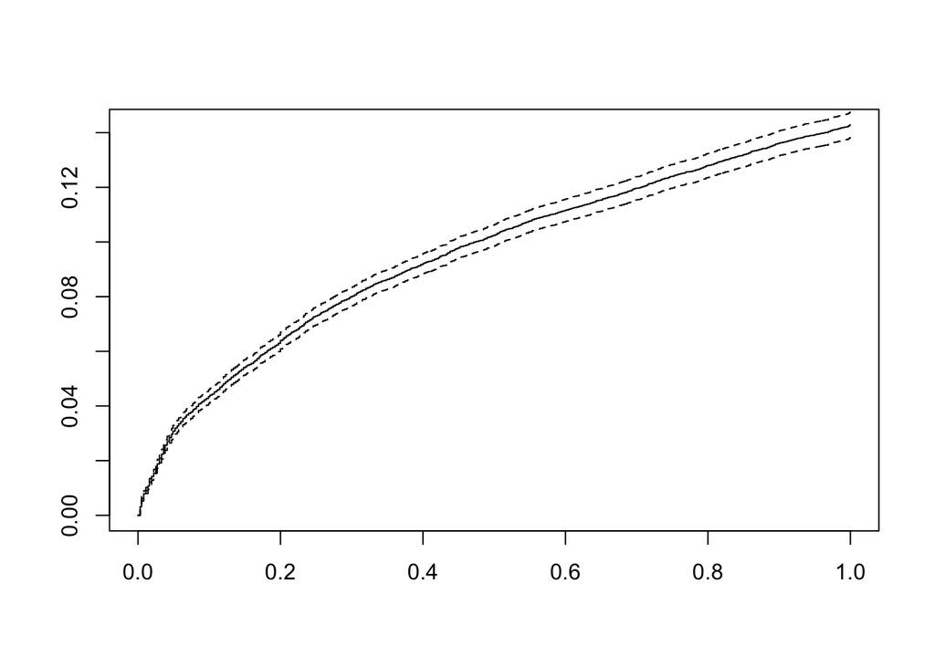

```r
plot(survfit(fit), fun = "cumhaz", mark.time = FALSE)
```